# PLS - Agencias

Artículo 1 (versión 2)

Roberto Gil-Saura

2/4/2021

NOTA: Modelo completo, pero quitamos LOY3.

# 1 Consideraciones sobre la muestra

# 2 Modelización

Seguidamente mostramos el modelo de medida (outer model) y el modelo estructural (inner model), establecidos a partir de las hipótesis lanzadas.

El modelo de medida es el siguiente:

[interactive chart not shown]

Modelo de medida

El modelo estructural es el siguiente:

[interactive chart not shown]

Modelo estructural

## 2.1 Análisis de la fiabilidad

Para el modelo de medida se han considerado constructos reflectivos. De este modo, el primer paso debe ser observar el resumen de los indicadores de fiabilidad, consistencia interna y validez.

El resultado del análisis muestra todas las escalas que apoyan las variables latentes tienen un *Cronbach’s alpha* mayor que 0.7, completado por una fiabilidad del compuesto *rhoC* también por encima de 0.7. para valores superiores a 0.9[^1].

```
             alpha    rhoC     AVE    rhoA
ICT        "0.891" "0.922" "0.707" "0.910"
VCC        "0.829" "0.864" "0.523" "0.879"
TRUST      "0.842" "0.905" "0.762" "0.849"
COMMITMENT "0.894" "0.926" "0.757" "0.901"
ECOSAT     "0.789" "0.880" "0.714" "0.828"
SOCSAT     "0.832" "0.898" "0.747" "0.890"
LOY        "0.839" "0.903" "0.756" "0.850"

Alpha, rhoC, and rhoA should exceed 0.7 while AVE should exceed 0.5
```

## 2.2 Validez convergente

### 2.2.1 AVE

Del mismo modo, para evaluar la *validez convergente* o grado con el que una medida correlaciona positivamente con medidas alternativas del mismo constructo, usamos el coeficiente *AVE (average variance extracted)* que también cumple con la expectativa de estar por encima de 0.5.

```
             alpha    rhoC     AVE    rhoA
ICT        "0.891" "0.922" "0.707" "0.910"
VCC        "0.829" "0.864" "0.523" "0.879"
TRUST      "0.842" "0.905" "0.762" "0.849"
COMMITMENT "0.894" "0.926" "0.757" "0.901"
ECOSAT     "0.789" "0.880" "0.714" "0.828"
SOCSAT     "0.832" "0.898" "0.747" "0.890"
LOY        "0.839" "0.903" "0.756" "0.850"

Alpha, rhoC, and rhoA should exceed 0.7 while AVE should exceed 0.5
```

Los indicadores son mostrados de forma conjunta en el siguiente gráfico.

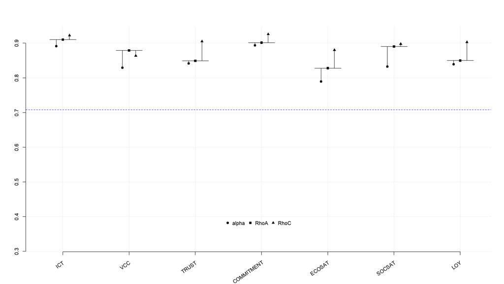

Tabla de fiabilidad

### 2.2.2 Análisis de las cargas

Por otro lado, es importante analizar también las cargas o *loadings*, indicadores de la fiabilidad del indicador en el constructo, y que deberían ser mayores de 0.7 para retener el indicador; para aquellas que están entre 0.4 y 0.7 debe ser analizado el comportamiento del constructo ante una eliminación del indicador con carga baja[^2].

```
              ICT   VCC TRUST COMMITMENT ECOSAT SOCSAT   LOY
ICT1        0.906 0.000 0.000      0.000  0.000  0.000 0.000
ICT2        0.925 0.000 0.000      0.000  0.000  0.000 0.000
ICT3        0.930 0.000 0.000      0.000  0.000  0.000 0.000
ICT4        0.761 0.000 0.000      0.000  0.000  0.000 0.000
ICT5        0.643 0.000 0.000      0.000  0.000  0.000 0.000
VCC1        0.000 0.796 0.000      0.000  0.000  0.000 0.000
VCC2        0.000 0.834 0.000      0.000  0.000  0.000 0.000
VCC3        0.000 0.629 0.000      0.000  0.000  0.000 0.000
VCC4        0.000 0.861 0.000      0.000  0.000  0.000 0.000
VCC5        0.000 0.679 0.000      0.000  0.000  0.000 0.000
VCC6        0.000 0.458 0.000      0.000 -0.000  0.000 0.000
TRUST1      0.000 0.000 0.938      0.000  0.000  0.000 0.000
TRUST2      0.000 0.000 0.816      0.000  0.000  0.000 0.000
TRUST3      0.000 0.000 0.860      0.000  0.000  0.000 0.000
COMMITMENT1 0.000 0.000 0.000      0.868  0.000  0.000 0.000
COMMITMENT2 0.000 0.000 0.000      0.895  0.000  0.000 0.000
COMMITMENT3 0.000 0.000 0.000      0.840  0.000  0.000 0.000
COMMITMENT4 0.000 0.000 0.000      0.877  0.000  0.000 0.000
SOCSAT1     0.000 0.000 0.000      0.000  0.000  0.744 0.000
SOCSAT2     0.000 0.000 0.000      0.000  0.000  0.926 0.000
SOCSAT3     0.000 0.000 0.000      0.000  0.000  0.911 0.000
ECOSAT1     0.000 0.000 0.000      0.000  0.933  0.000 0.000
ECOSAT2     0.000 0.000 0.000      0.000  0.915  0.000 0.000
ECOSAT3     0.000 0.000 0.000      0.000  0.659  0.000 0.000
LOY1        0.000 0.000 0.000      0.000  0.000  0.000 0.893
LOY2        0.000 0.000 0.000      0.000  0.000  0.000 0.822
LOY4        0.000 0.000 0.000      0.000  0.000  0.000 0.892
```

## 2.3 Validez discriminante

### 2.3.1 Cross-loadings

Para el análisis de la validez discriminante o capacidad de un constructo de ser realmente distinto a otros, utilizamos las denominadas *cross-loadings*, que miden esa capacidad del constructo. En la tabla adjunta se puede observar en cada indicador carga de forma superior en su variable latente, siendo el resto de cargas de menor intensidad.

```
              ICT   VCC TRUST COMMITMENT ECOSAT SOCSAT   LOY
ICT1        0.906 0.452 0.081      0.213  0.241  0.236 0.323
ICT2        0.925 0.438 0.123      0.241  0.241  0.215 0.309
ICT3        0.930 0.476 0.142      0.281  0.321  0.285 0.344
ICT4        0.761 0.357 0.077      0.163  0.257  0.176 0.224
ICT5        0.643 0.342 0.080      0.190  0.047  0.204 0.179
VCC1        0.424 0.796 0.441      0.555  0.616  0.415 0.646
VCC2        0.431 0.834 0.324      0.529  0.548  0.380 0.581
VCC3        0.267 0.629 0.070      0.213  0.086  0.311 0.234
VCC4        0.410 0.861 0.354      0.518  0.436  0.446 0.551
VCC5        0.308 0.679 0.125      0.284  0.091  0.226 0.254
VCC6        0.237 0.458 0.122      0.136 -0.056  0.254 0.104
TRUST1      0.103 0.362 0.938      0.544  0.478  0.545 0.490
TRUST2      0.095 0.309 0.816      0.497  0.503  0.394 0.470
TRUST3      0.121 0.334 0.860      0.526  0.385  0.488 0.429
COMMITMENT1 0.249 0.563 0.518      0.868  0.518  0.478 0.612
COMMITMENT2 0.253 0.574 0.521      0.895  0.532  0.506 0.649
COMMITMENT3 0.197 0.392 0.529      0.840  0.257  0.468 0.396
COMMITMENT4 0.207 0.450 0.521      0.877  0.362  0.518 0.475
SOCSAT1     0.218 0.356 0.223      0.327  0.428  0.744 0.452
SOCSAT2     0.222 0.441 0.576      0.524  0.618  0.926 0.633
SOCSAT3     0.258 0.446 0.540      0.569  0.667  0.911 0.730
ECOSAT1     0.198 0.422 0.512      0.450  0.933  0.583 0.621
ECOSAT2     0.211 0.431 0.525      0.486  0.915  0.581 0.620
ECOSAT3     0.307 0.450 0.243      0.285  0.659  0.566 0.545
LOY1        0.290 0.594 0.490      0.555  0.660  0.677 0.893
LOY2        0.282 0.488 0.418      0.503  0.585  0.499 0.822
LOY4        0.303 0.540 0.473      0.565  0.588  0.681 0.892
```

### 2.3.2 Fornell-Larcker

El criterio de Fornell-Larcker, compara la raíz cuadrado del *AVE* con la correlación de las variables latentes. La raíz cuadrada del AVE de cada constructo, debería ser más grande que la más alta correlación con cualquier otro constructo. Se puede observar en la tabla siguiente que el valor en la diagonal principal, es mayor que el resto de valores en la parte inferior de la matriz.

```
             ICT   VCC TRUST COMMITMENT ECOSAT SOCSAT   LOY
ICT        0.841     .     .          .      .      .     .
VCC        0.496 0.723     .          .      .      .     .
TRUST      0.122 0.385 0.873          .      .      .     .
COMMITMENT 0.262 0.576 0.599      0.870      .      .     .
ECOSAT     0.272 0.507 0.521      0.491  0.845      .     .
SOCSAT     0.268 0.482 0.548      0.566  0.677  0.864     .
LOY        0.335 0.625 0.531      0.623  0.704  0.718 0.870

FL Criteria table reports square root of AVE on the diagonal and construct correlations on the lower triangle.
```

### 2.3.3 HTMT

Por último el HTMT es un ratio que si es mayor que 0.90 indica una pérdida de validez discriminante.

```
             ICT   VCC TRUST COMMITMENT ECOSAT SOCSAT LOY
ICT            .     .     .          .      .      .   .
VCC        0.553     .     .          .      .      .   .
TRUST      0.150 0.475     .          .      .      .   .
COMMITMENT 0.290 0.591 0.692          .      .      .   .
ECOSAT     0.339 0.584 0.625      0.564      .      .   .
SOCSAT     0.313 0.565 0.614      0.634  0.832      .   .
LOY        0.382 0.640 0.630      0.706  0.871  0.828   .
```

## 2.4 Análisis del modelo estructural

- R<sup>2</sup>, coeficiente de determinación y/o % de varianza explicada
- f<sup>2</sup> y q<sup>2</sup> efecto tamaño
- Q<sup>2</sup>, relevancia predictiva

### 2.4.1 Colinealidad

Colinealidad, estudiada con los inner VIF value (inverso de la tolerancia). Todos los valores deben ser menores a 0.20 en tolerancia, lo que implica ser menores a 5 en VIF. Los valores se dan para cada constructo.

#### 2.4.1.1 vif items

```
ICT :
 ICT1  ICT2  ICT3  ICT4  ICT5
5.577 7.862 5.074 1.796 1.402

VCC :
 VCC1  VCC2  VCC3  VCC4  VCC5  VCC6
3.056 3.057 2.747 2.385 2.304 2.660

TRUST :
TRUST1 TRUST2 TRUST3
 3.427  1.825  2.452

COMMITMENT :
COMMITMENT1 COMMITMENT2 COMMITMENT3 COMMITMENT4
      2.966       3.256       3.379       3.742

ECOSAT :
ECOSAT1 ECOSAT2 ECOSAT3
  4.052   3.819   1.232

SOCSAT :
SOCSAT1 SOCSAT2 SOCSAT3
  1.569   2.801   2.431

LOY :
 LOY1  LOY2  LOY4
2.168 1.734 2.220
```

#### 2.4.1.2 vif antecedents

```
VCC :
ICT
  .

TRUST :
VCC
  .

COMMITMENT :
  VCC TRUST
1.173 1.173

ECOSAT :
COMMITMENT      TRUST
     1.559      1.559

SOCSAT :
COMMITMENT      TRUST
     1.559      1.559

LOY :
ECOSAT SOCSAT
 1.845  1.845
```

#### 2.4.1.3 Paths

```
             VCC TRUST COMMITMENT ECOSAT SOCSAT   LOY
R^2        0.246 0.148      0.499  0.322  0.388 0.603
AdjR^2     0.243 0.144      0.495  0.316  0.383 0.600
ICT        0.496     .          .      .      .     .
VCC            . 0.385      0.406      .      .     .
TRUST          .     .      0.443  0.354  0.326     .
COMMITMENT     .     .          .  0.279  0.371     .
ECOSAT         .     .          .      .      . 0.401
SOCSAT         .     .          .      .      . 0.446
```

### 2.4.2 R<sup>2</sup>

Buscar R<sup>2</sup> mayores de 0.7, aunque valores alrededor de 0.25 sean aceptados según ámbitos; (sustancial mayor que 0.75, moderado alrededor de 0.5 y débil, 0.25). Usar R<sup>2</sup><sub>adj</sub> para comparar modelos con diferente número de constructos y/u observaciones.

```
             VCC     TRUST COMMITMENT    ECOSAT    SOCSAT       LOY
Rsq    0.2459584 0.1478427  0.4988894 0.3218080 0.3882371 0.6029480
AdjRsq 0.2429897 0.1444878  0.4949281 0.3164468 0.3834011 0.5998093
```

### 2.4.3 f<sup>2</sup> - effect sizes

El f<sup>2</sup> permite evaluar la contribución de cada constructo exógeno a la R<sup>2</sup> de un constructo endógeno. Los valores de 0.02, 0.15 y 0.35 indican un efecto pequeño, mediano o grande sobre el constructo endógeno.

```
             ICT   VCC TRUST COMMITMENT ECOSAT SOCSAT   LOY
ICT        0.000 0.326 0.000      0.000  0.000  0.000 0.000
VCC        0.000 0.000 0.173      0.279  0.000  0.000 0.000
TRUST      0.000 0.000 0.000      0.325  0.120  0.114 0.000
COMMITMENT 0.000 0.000 0.000      0.000  0.073  0.139 0.000
ECOSAT     0.000 0.000 0.000      0.000  0.000  0.000 0.208
SOCSAT     0.000 0.000 0.000      0.000  0.000  0.000 0.269
LOY        0.000 0.000 0.000      0.000  0.000  0.000 0.000
```

### 2.4.4 Efectos

#### 2.4.4.1 Totales

```
             ICT   VCC TRUST COMMITMENT ECOSAT SOCSAT   LOY
ICT        0.000 0.496 0.191      0.286  0.147  0.168 0.134
VCC        0.000 0.000 0.385      0.576  0.297  0.339 0.271
TRUST      0.000 0.000 0.000      0.443  0.478  0.490 0.410
COMMITMENT 0.000 0.000 0.000      0.000  0.279  0.371 0.278
ECOSAT     0.000 0.000 0.000      0.000  0.000  0.000 0.401
SOCSAT     0.000 0.000 0.000      0.000  0.000  0.000 0.446
LOY        0.000 0.000 0.000      0.000  0.000  0.000 0.000
```

#### 2.4.4.2 Indirectos

```
             ICT   VCC TRUST COMMITMENT ECOSAT SOCSAT   LOY
ICT        0.000 0.000 0.191      0.286  0.147  0.168 0.134
VCC        0.000 0.000 0.000      0.170  0.297  0.339 0.271
TRUST      0.000 0.000 0.000      0.000  0.124  0.164 0.410
COMMITMENT 0.000 0.000 0.000      0.000  0.000  0.000 0.278
ECOSAT     0.000 0.000 0.000      0.000  0.000  0.000 0.000
SOCSAT     0.000 0.000 0.000      0.000  0.000  0.000 0.000
LOY        0.000 0.000 0.000      0.000  0.000  0.000 0.000
```

### 2.4.5 it_criteria

```
        VCC   TRUST COMMITMENT  ECOSAT   SOCSAT      LOY
AIC -69.273 -37.958   -171.880 -94.413 -120.803 -231.466
BIC -62.182 -30.868   -161.244 -83.778 -110.168 -220.831
```

# 3 Modelización con bootstrapping

*Bootstrapping* para calcular la significatividad de los paths estimados. Habitualmente se trabaja con un 5% (t > 1.96) lo que implica significatividad al 95%. Podemos cambiar al 10 o al 1 según ámbito. Usar doble *bootstrapping* si hay menos de 4 constructos.

```
Bootstrapping model using seminr...
SEMinR Model successfully bootstrapped
```

## 3.1 Structural paths

```
                       Original Est. Bootstrap Mean Bootstrap SD T Stat. 2.5% CI 97.5% CI
ICT  ->  VCC                   0.496          0.500        0.055   8.946   0.386    0.601
VCC  ->  TRUST                 0.385          0.387        0.055   6.936   0.272    0.489
VCC  ->  COMMITMENT            0.406          0.408        0.048   8.409   0.310    0.497
TRUST  ->  COMMITMENT          0.443          0.441        0.054   8.225   0.335    0.544
TRUST  ->  ECOSAT              0.354          0.355        0.075   4.741   0.205    0.497
TRUST  ->  SOCSAT              0.326          0.325        0.077   4.255   0.174    0.477
COMMITMENT  ->  ECOSAT         0.279          0.280        0.071   3.910   0.145    0.425
COMMITMENT  ->  SOCSAT         0.371          0.370        0.081   4.560   0.207    0.526
ECOSAT  ->  LOY                0.401          0.409        0.070   5.772   0.270    0.540
SOCSAT  ->  LOY                0.446          0.439        0.073   6.092   0.294    0.580
```

## 3.2 Bootstrapped weights

```
                            Original Est. Bootstrap Mean Bootstrap SD T Stat. 2.5% CI 97.5% CI
ICT1  ->  ICT                       0.258          0.258        0.015  16.816   0.229    0.289
ICT2  ->  ICT                       0.250          0.250        0.016  15.809   0.217    0.280
ICT3  ->  ICT                       0.272          0.273        0.018  15.354   0.242    0.310
ICT4  ->  ICT                       0.204          0.204        0.029   7.030   0.146    0.259
ICT5  ->  ICT                       0.195          0.194        0.026   7.488   0.142    0.244
VCC1  ->  VCC                       0.321          0.321        0.024  13.391   0.279    0.373
VCC2  ->  VCC                       0.295          0.295        0.020  14.766   0.258    0.336
VCC3  ->  VCC                       0.130          0.127        0.028   4.618   0.069    0.177
VCC4  ->  VCC                       0.293          0.293        0.016  18.299   0.263    0.325
VCC5  ->  VCC                       0.167          0.168        0.024   7.099   0.118    0.211
VCC6  ->  VCC                       0.111          0.109        0.027   4.096   0.051    0.157
TRUST1  ->  TRUST                   0.411          0.411        0.016  26.397   0.380    0.442
TRUST2  ->  TRUST                   0.363          0.366        0.025  14.474   0.319    0.420
TRUST3  ->  TRUST                   0.370          0.368        0.018  20.069   0.330    0.403
COMMITMENT1  ->  COMMITMENT         0.308          0.308        0.017  18.175   0.278    0.345
COMMITMENT2  ->  COMMITMENT         0.317          0.317        0.017  19.004   0.287    0.352
COMMITMENT3  ->  COMMITMENT         0.246          0.246        0.015  15.862   0.214    0.275
COMMITMENT4  ->  COMMITMENT         0.277          0.276        0.014  19.549   0.247    0.303
SOCSAT1  ->  SOCSAT                 0.260          0.260        0.020  12.851   0.218    0.298
SOCSAT2  ->  SOCSAT                 0.420          0.420        0.015  28.575   0.390    0.448
SOCSAT3  ->  SOCSAT                 0.458          0.459        0.017  27.725   0.429    0.495
ECOSAT1  ->  ECOSAT                 0.425          0.426        0.016  26.873   0.397    0.459
ECOSAT2  ->  ECOSAT                 0.433          0.434        0.016  26.983   0.405    0.468
ECOSAT3  ->  ECOSAT                 0.314          0.312        0.027  11.781   0.255    0.359
LOY1  ->  LOY                       0.416          0.416        0.018  22.745   0.383    0.455
LOY2  ->  LOY                       0.335          0.336        0.018  18.859   0.301    0.371
LOY4  ->  LOY                       0.396          0.395        0.019  21.363   0.358    0.430
```

## 3.3 Bootstrapped loadings

```
                            Original Est. Bootstrap Mean Bootstrap SD T Stat. 2.5% CI 97.5% CI
ICT1  ->  ICT                       0.906          0.906        0.016  55.775   0.872    0.935
ICT2  ->  ICT                       0.925          0.925        0.015  62.393   0.890    0.949
ICT3  ->  ICT                       0.930          0.930        0.013  72.897   0.903    0.952
ICT4  ->  ICT                       0.761          0.760        0.049  15.390   0.651    0.843
ICT5  ->  ICT                       0.643          0.642        0.047  13.599   0.541    0.726
VCC1  ->  VCC                       0.796          0.796        0.029  27.031   0.733    0.850
VCC2  ->  VCC                       0.834          0.833        0.033  24.979   0.761    0.892
VCC3  ->  VCC                       0.629          0.623        0.061  10.304   0.490    0.725
VCC4  ->  VCC                       0.861          0.860        0.019  44.918   0.819    0.893
VCC5  ->  VCC                       0.679          0.676        0.054  12.619   0.562    0.771
VCC6  ->  VCC                       0.458          0.453        0.076   6.062   0.288    0.584
TRUST1  ->  TRUST                   0.938          0.938        0.011  88.000   0.914    0.955
TRUST2  ->  TRUST                   0.816          0.818        0.024  33.511   0.768    0.862
TRUST3  ->  TRUST                   0.860          0.856        0.027  31.485   0.795    0.901
COMMITMENT1  ->  COMMITMENT         0.868          0.868        0.020  42.439   0.824    0.904
COMMITMENT2  ->  COMMITMENT         0.895          0.896        0.015  59.633   0.863    0.921
COMMITMENT3  ->  COMMITMENT         0.840          0.839        0.028  30.505   0.778    0.888
COMMITMENT4  ->  COMMITMENT         0.877          0.876        0.022  39.324   0.827    0.913
SOCSAT1  ->  SOCSAT                 0.744          0.741        0.040  18.829   0.656    0.813
SOCSAT2  ->  SOCSAT                 0.926          0.926        0.011  82.954   0.902    0.946
SOCSAT3  ->  SOCSAT                 0.911          0.911        0.012  75.941   0.886    0.932
ECOSAT1  ->  ECOSAT                 0.933          0.933        0.012  80.227   0.910    0.955
ECOSAT2  ->  ECOSAT                 0.915          0.916        0.016  57.327   0.879    0.941
ECOSAT3  ->  ECOSAT                 0.659          0.656        0.050  13.180   0.550    0.743
LOY1  ->  LOY                       0.893          0.893        0.014  65.899   0.865    0.918
LOY2  ->  LOY                       0.822          0.822        0.034  24.234   0.748    0.879
LOY4  ->  LOY                       0.892          0.891        0.016  54.582   0.857    0.920
```

## 3.4 Bootstrapped HTMT

```
                       Original Est. Bootstrap Mean Bootstrap SD T Stat. 2.5% CI 97.5% CI
ICT  ->  VCC                   0.553          0.552        0.065   8.449   0.416    0.672
ICT  ->  TRUST                 0.150          0.164        0.057   2.640   0.071    0.288
ICT  ->  COMMITMENT            0.290          0.291        0.067   4.358   0.160    0.421
ICT  ->  ECOSAT                0.339          0.345        0.070   4.834   0.202    0.476
ICT  ->  SOCSAT                0.313          0.314        0.075   4.166   0.162    0.456
ICT  ->  LOY                   0.382          0.385        0.072   5.310   0.238    0.523
VCC  ->  TRUST                 0.475          0.474        0.052   9.200   0.369    0.571
VCC  ->  COMMITMENT            0.591          0.591        0.044  13.301   0.502    0.677
VCC  ->  ECOSAT                0.584          0.599        0.044  13.382   0.516    0.687
VCC  ->  SOCSAT                0.565          0.563        0.067   8.432   0.424    0.685
VCC  ->  LOY                   0.640          0.644        0.052  12.315   0.540    0.745
TRUST  ->  COMMITMENT          0.692          0.690        0.053  12.984   0.581    0.789
TRUST  ->  ECOSAT              0.625          0.625        0.074   8.495   0.478    0.761
TRUST  ->  SOCSAT              0.614          0.616        0.061  10.066   0.496    0.733
TRUST  ->  LOY                 0.630          0.629        0.070   9.064   0.487    0.756
COMMITMENT  ->  ECOSAT         0.564          0.564        0.068   8.291   0.427    0.694
COMMITMENT  ->  SOCSAT         0.634          0.632        0.068   9.262   0.489    0.760
COMMITMENT  ->  LOY            0.706          0.705        0.049  14.295   0.602    0.795
ECOSAT  ->  SOCSAT             0.832          0.834        0.050  16.699   0.727    0.921
ECOSAT  ->  LOY                0.871          0.873        0.055  15.743   0.751    0.965
SOCSAT  ->  LOY                0.828          0.827        0.047  17.588   0.726    0.911
```

## 3.5 Total effects (paths)

```
                       Original Est. Bootstrap Mean Bootstrap SD T Stat. 2.5% CI 97.5% CI
ICT  ->  VCC                   0.496          0.500        0.055   8.946   0.386    0.601
ICT  ->  TRUST                 0.191          0.194        0.037   5.173   0.122    0.266
ICT  ->  COMMITMENT            0.286          0.290        0.038   7.543   0.214    0.363
ICT  ->  ECOSAT                0.147          0.151        0.029   5.059   0.097    0.211
ICT  ->  SOCSAT                0.168          0.171        0.030   5.569   0.115    0.233
ICT  ->  LOY                   0.134          0.138        0.026   5.170   0.090    0.192
VCC  ->  TRUST                 0.385          0.387        0.055   6.936   0.272    0.489
VCC  ->  COMMITMENT            0.576          0.579        0.036  15.943   0.503    0.646
VCC  ->  ECOSAT                0.297          0.302        0.044   6.756   0.216    0.388
VCC  ->  SOCSAT                0.339          0.342        0.045   7.517   0.252    0.429
VCC  ->  LOY                   0.271          0.275        0.040   6.716   0.195    0.355
TRUST  ->  COMMITMENT          0.443          0.441        0.054   8.225   0.335    0.544
TRUST  ->  ECOSAT              0.478          0.478        0.059   8.100   0.360    0.589
TRUST  ->  SOCSAT              0.490          0.488        0.060   8.130   0.366    0.603
TRUST  ->  LOY                 0.410          0.411        0.050   8.277   0.313    0.509
COMMITMENT  ->  ECOSAT         0.279          0.280        0.071   3.910   0.145    0.425
COMMITMENT  ->  SOCSAT         0.371          0.370        0.081   4.560   0.207    0.526
COMMITMENT  ->  LOY            0.278          0.280        0.063   4.418   0.159    0.403
ECOSAT  ->  LOY                0.401          0.409        0.070   5.772   0.270    0.540
SOCSAT  ->  LOY                0.446          0.439        0.073   6.092   0.294    0.580
```

## 3.6 Plot model

[interactive chart not shown]

Modelo con bootstrapping

# 4 Predicción (seminr)

RMSE: root mean squared residuals MAE: mean absolute residuals

```
PLS in-sample metrics:
      VCC1  VCC2  VCC3  VCC4  VCC5  VCC6 TRUST1 TRUST2 TRUST3 COMMITMENT1 COMMITMENT2 COMMITMENT3 COMMITMENT4 ECOSAT1 ECOSAT2 ECOSAT3 SOCSAT1 SOCSAT2 SOCSAT3  LOY1  LOY2  LOY4
RMSE 1.682 1.443 1.488 1.351 1.152 1.328  0.767  1.237  0.736       1.081       0.862       0.843       0.876   1.277   1.245   1.330   0.916   0.735   0.898 0.785 1.254 0.833
MAD  1.433 1.168 1.200 1.083 0.914 1.104  0.580  1.023  0.566       0.854       0.704       0.615       0.655   1.017   1.003   0.993   0.709   0.559   0.681 0.611 0.987 0.624

PLS out-of-sample metrics:
      VCC1  VCC2  VCC3  VCC4  VCC5  VCC6 TRUST1 TRUST2 TRUST3 COMMITMENT1 COMMITMENT2 COMMITMENT3 COMMITMENT4 ECOSAT1 ECOSAT2 ECOSAT3 SOCSAT1 SOCSAT2 SOCSAT3  LOY1  LOY2  LOY4
RMSE 1.697 1.459 1.504 1.369 1.164 1.340  0.777  1.247  0.747       1.105       0.881       0.852       0.887   1.301   1.262   1.342   0.927   0.750   0.913 0.792 1.266 0.846
MAD  1.442 1.179 1.212 1.093 0.923 1.116  0.585  1.032  0.572       0.870       0.717       0.621       0.665   1.034   1.016   1.002   0.716   0.569   0.691 0.617 0.993 0.629

LM in-sample metrics:
      VCC1  VCC2  VCC3  VCC4  VCC5  VCC6 TRUST1 TRUST2 TRUST3 COMMITMENT1 COMMITMENT2 COMMITMENT3 COMMITMENT4 ECOSAT1 ECOSAT2 ECOSAT3 SOCSAT1 SOCSAT2 SOCSAT3  LOY1  LOY2  LOY4
RMSE 1.074 1.062 1.139 1.066 0.979 1.013  0.566  0.804  0.562       0.898       0.748       0.726       0.790   0.898   0.875   0.856   0.620   0.559   0.632 0.666 1.073 0.694
MAD  0.857 0.850 0.893 0.869 0.772 0.784  0.445  0.631  0.451       0.696       0.599       0.539       0.576   0.714   0.691   0.635   0.487   0.436   0.494 0.514 0.856 0.537

LM out-of-sample metrics:
      VCC1  VCC2  VCC3  VCC4  VCC5  VCC6 TRUST1 TRUST2 TRUST3 COMMITMENT1 COMMITMENT2 COMMITMENT3 COMMITMENT4 ECOSAT1 ECOSAT2 ECOSAT3 SOCSAT1 SOCSAT2 SOCSAT3  LOY1  LOY2  LOY4
RMSE 1.197 1.227 1.320 1.249 1.174 1.172  0.670  1.003  0.667       1.043       0.863       0.885       0.953   1.068   1.040   1.047   0.753   0.682   0.758 0.804 1.262 0.872
MAD  0.951 0.960 1.017 1.002 0.898 0.886  0.515  0.754  0.531       0.789       0.687       0.631       0.671   0.824   0.797   0.748   0.568   0.513   0.577 0.601 0.974 0.630
```

# 5 Relevancia predictiva (matrixpls)

(con matrixpls -Aldás y Uriel, 2017-)

```
 matrixpls parameter estimates
                              Est.
ICT~VCC                 0.49452976
VCC~TRUST               0.05792255
VCC~COMMITMENT          0.53366936
TRUST~COMMITMENT        0.39226074
TRUST~ECOSAT            0.20125303
COMMITMENT~ECOSAT       0.19517134
TRUST~SOCSAT            0.19158309
COMMITMENT~SOCSAT       0.43469381
ECOSAT~LOY              0.70228191
SOCSAT~LOY              0.71819321
ICT=~ICT1               0.90526121
ICT=~ICT2               0.92450944
ICT=~ICT3               0.92946511
ICT=~ICT4               0.76146795
ICT=~ICT5               0.64633127
VCC=~VCC1               0.78073363
VCC=~VCC2               0.82516686
VCC=~VCC3               0.64679190
VCC=~VCC4               0.86142715
VCC=~VCC5               0.69434186
VCC=~VCC6               0.47759676
TRUST=~TRUST1           0.93841265
TRUST=~TRUST2           0.81355358
TRUST=~TRUST3           0.86199653
COMMITMENT=~COMMITMENT1 0.86366668
COMMITMENT=~COMMITMENT2 0.89194473
COMMITMENT=~COMMITMENT3 0.84539876
COMMITMENT=~COMMITMENT4 0.88068609
ECOSAT=~ECOSAT1         0.93590222
ECOSAT=~ECOSAT2         0.91894965
ECOSAT=~ECOSAT3         0.65041095
SOCSAT=~SOCSAT1         0.74013576
SOCSAT=~SOCSAT2         0.92736751
SOCSAT=~SOCSAT3         0.91198860
LOY=~LOY1               0.89312091
LOY=~LOY2               0.82304398
LOY=~LOY4               0.89104828

```

[output cut: 108 more lines]

```
ICT        0.0000000 0.0000000 0.0000000  0.0000000 0.0000000 0.0000000 0.0000000
VCC        0.5529984 0.0000000 0.0000000  0.0000000 0.0000000 0.0000000 0.0000000
TRUST      0.1395340 0.3885449 0.0000000  0.0000000 0.0000000 0.0000000 0.0000000
COMMITMENT 0.2901720 0.5855432 0.6921706  0.0000000 0.0000000 0.0000000 0.0000000
ECOSAT     0.3319744 0.5057293 0.6253619  0.5636538 0.0000000 0.0000000 0.0000000
SOCSAT     0.3126115 0.5653729 0.6143936  0.6343595 0.8324163 0.0000000 0.0000000
LOY        0.3822888 0.6402719 0.6302629  0.7061534 0.8712458 0.8284748 0.0000000

 Composite equilevance indices

 CEI individual
       ICT        VCC      TRUST COMMITMENT     ECOSAT     SOCSAT        LOY
 0.9987043  0.9729496  0.9998294  0.9995342  0.9957160  0.9936386  0.9992882

 CEI total: 0.9729496
```

```
 Q2 predictive relevance statistics

 Overall Q2
0.2655352
 Block Q2
       ICT        VCC      TRUST COMMITMENT     ECOSAT     SOCSAT        LOY
0.06362387 0.21939600 0.44055803 0.26856029 0.51569002 0.36170127 0.63102589

 Indicator Q2
      TRUST1       TRUST2       TRUST3  COMMITMENT1  COMMITMENT2  COMMITMENT3  COMMITMENT4         VCC1         VCC2         VCC3         VCC4         VCC5         VCC6      ECOSAT1      ECOSAT2      ECOSAT3      SOCSAT1      SOCSAT2      SOCSAT3         LOY1         LOY2         LOY4         ICT1  …
 0.243754350  0.577243215 -0.974759456  0.388496490  0.464481477 -0.388466816 -0.168579268  0.219229424  0.146091635  0.291493781  0.015068434  0.171313354  0.389980363  0.553148526  0.566045905  0.254871814 -0.194926442 -0.055730731  0.743033895  0.788828598  0.503384302  0.827485786  0.051580950  …
```

# 6 Potencia (matrixpls)

```
     Multiple regression power calculation

              u = 6
              v = 250
             f2 = 0.15
      sig.level = 0.05
          power = 0.9990871
```

```
     Multiple regression power calculation

              u = 6
              v = 90.30998
             f2 = 0.15
      sig.level = 0.05
          power = 0.8
```

[^1]: En https://forum.smartpls.com/viewtopic.php?f=5&t=3805 hay una “discusión en torno al”greater than 0.9" de Primer PLS … de Hair; lo solventa un investigador / desarrollador de SmartPLS: https://www.researchgate.net/profile/Jan_Michael_Becker
[^2]: En nuestro caso al proceder con la eliminación de aquellas cargas menores de 0.7 no mejoraba significativamente el modelo